# Análisis exploratorio

Se realizará un análisis descriptivo/exploratorio para resumir y caracterizar la información recolectada. Para ello se utilizarán medidas de tendencia central (media, mediana), medidas de dispersión (desvío estándar, rango intercuartílico) y frecuencias absolutas y relativas, según el tipo de variable. Además, se incluirán tablas de frecuencia y gráficos que expresen la naturaleza de las variables y den un indicio de su posible relación (gráfico de barras, gráfico de dispersión tridimensional, gráfico de sectores, histogramas, entre otros).

Previo al análisis, se realizó un procesamiento de los datos disponibles para obtener las variables presentadas en el informe, que son:

- Cantidad de proteínas consumidas
- Porcentaje de proteínas según VCT
- Consumo de proteínas de origen animal
- Consumo de proteínas de origen vegetal
- Cantidad de hidratos de carbonos consumidos
- Porcentaje de hidratos de carbonos según VCT
- Cantidad de fibra consumida
- Cantidad de azucares consumidos (se estima como total de HC - total de fibras, ya que SARA no discrimina los azúcares)
- Cantidad de grasas consumidas
- Porcentaje de grasas según VCT
- Cantidad de grasas saturadas consumidas
- Cantidad de grasas monoinsaturadas consumidas
- Cantidad de grasas poliinsaturadas consumidas

# Variables socio-demográficas

## Rango de edad

Tabla 1. Frecuencia absoluta y relativa según el rango de edad

| Categoría | Frecuencia | Porcentaje |
| --- | --- | --- |
| 18-23 años | 12 | 17.6% |
| 24-29 años | 29 | 42.6% |
| 30-35 años | 5 | 7.4% |
| 36-41 años | 4 | 5.9% |
| 42-47 años | 3 | 4.4% |
| 48-54 años | 6 | 8.8% |
| 55-60 años | 9 | 13.2% |
| Total | 68 | 100% |

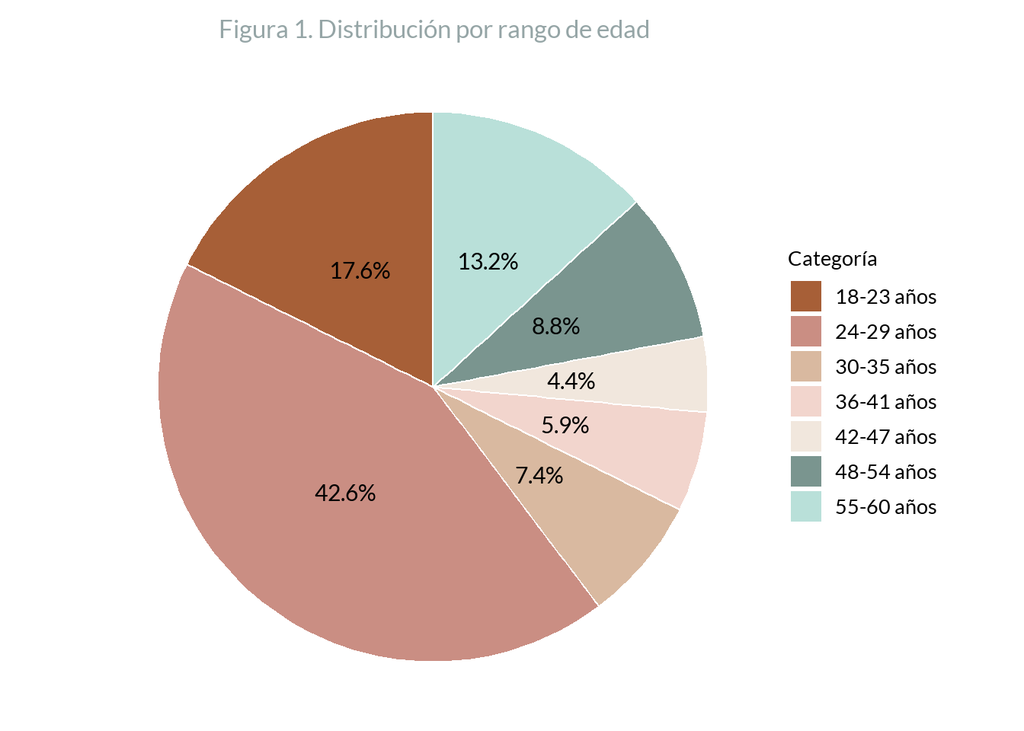

## Sexo

Tabla 2. Frecuencia absoluta y relativa según el sexo del individuo

| Categoría | Frecuencia | Porcentaje |
| --- | --- | --- |
| Femenino | 54 | 79.4% |
| Masculino | 14 | 20.6% |
| Total | 68 | 100% |

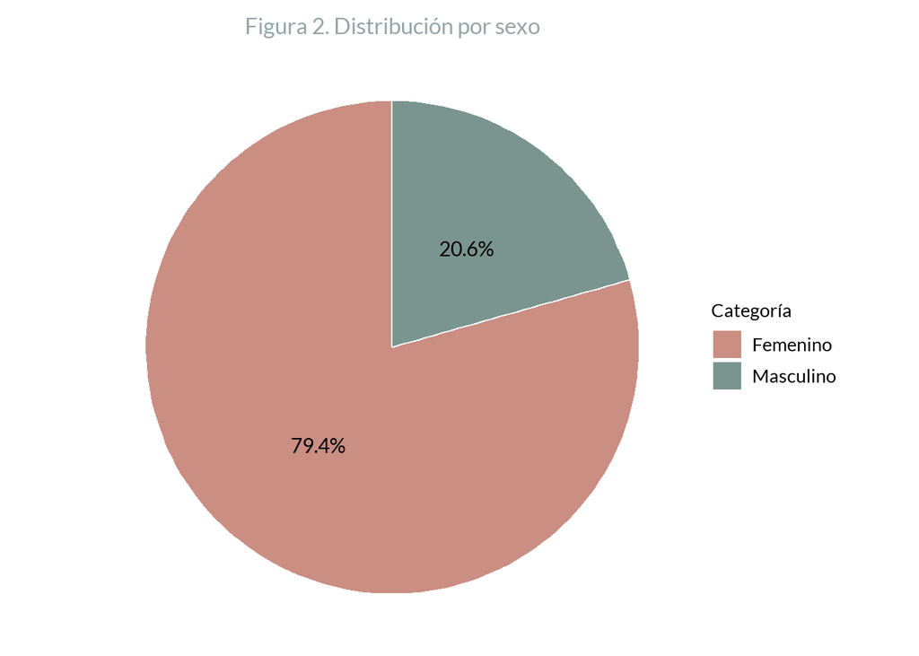

# Variables nutricionales

## Ingesta de proteínas

Tabla 3. Medidas resumen de la ingesta de proteínas por origen

| Origen | Min | Media | Máximo | Desvío |
| --- | --- | --- | --- | --- |
| Con carnes y derivados | 30.4 | 84.3 | 157.3 | 28.6 |
| Sin carnes | 26.2 | 44.7 | 60.2 | 17.2 |
| Total | 26.2 | 82.5 | 157.3 | 29.3 |

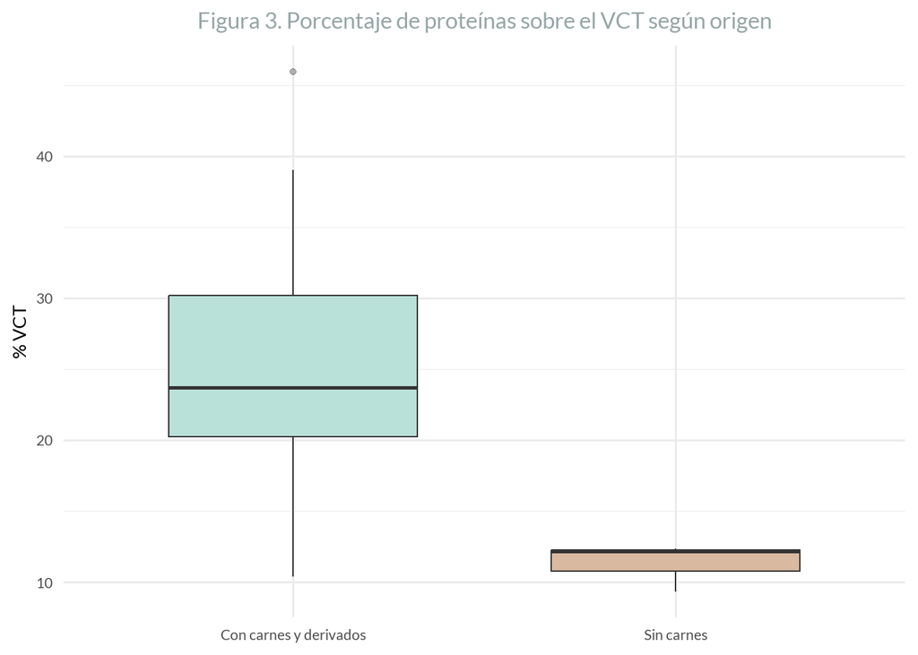

Se puede interpretar que quienes consumen carnes y derivados ingieren casi el doble de proteína (g) y destinan una fracción de energía notablemente mayor al macronutriente, con variabilidad amplia; los que no consumen carnes se concentran en porcentajes bajos y con poca dispersión.

## Ingesta de hidratos de carbono

Tabla 4. Medidas descriptivas de hidratos de carbono (totales, fibra y azúcares)

| Variable | Mín | Media | Máx | Desvío |
| --- | --- | --- | --- | --- |
| Carbohidratos totales (g) | 17.2 | 162.5 | 426.7 | 93.5 |
| Fibra (g) | 0.3 | 14.3 | 53.2 | 10.1 |
| Carbohidratos no fibrosos (≈ azúcares) (g) | 15.7 | 148.3 | 412.7 | 90.8 |

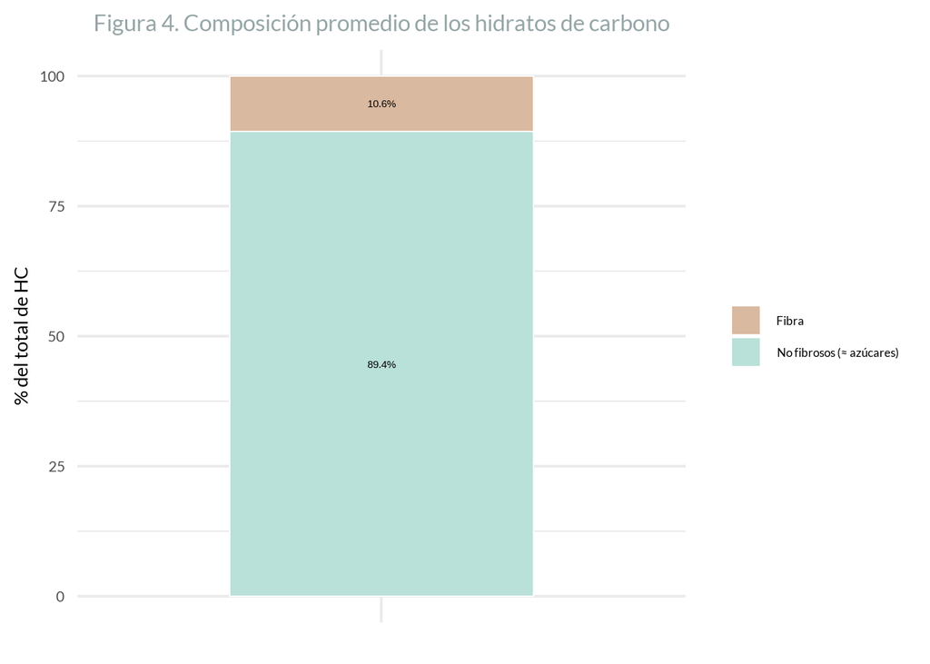

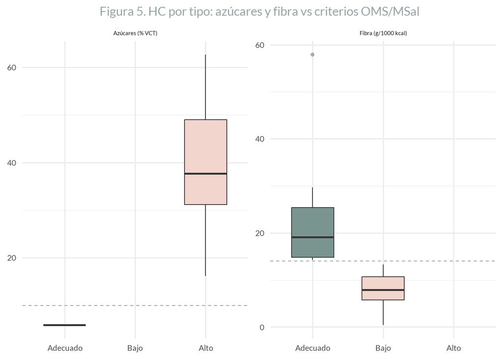

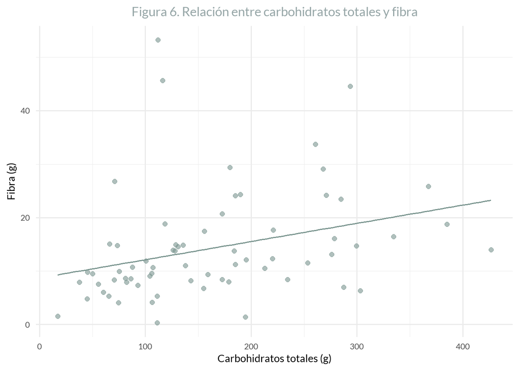

La ingesta media de hidratos de carbono fue 162,5 g/día (DE 93,5; 17,2–426,7). La fibra promedió 14,3 g/día (DE 10,1) y los carbohidratos no fibrosos (≈ azúcares) 148,3 g/día (DE 90,8). En términos relativos, la dieta se compuso mayormente de no fibrosos (~89%) y muy poco de fibra (~11%). El % de azúcares sobre el VCT superó con frecuencia el 10% recomendado, mientras que la fibra por 1000 kcal fue mayoritariamente “Bajo” (<14 g/1000 kcal). La asociación entre carbohidratos totales y fibra fue positiva pero débil, por lo que más carbohidratos no implica mayor aporte de fibra.

## Ingesta de grasas

Tabla 5. Medidas descriptivas de grasas (g)

| Variable | Mín | Media | Máx | Desvío |
| --- | --- | --- | --- | --- |
| Grasa total (g) | 5.3 | 52.5 | 144.1 | 26.4 |
| Saturadas (g) | 1.4 | 16.6 | 63.2 | 9.8 |
| Monoinsaturadas (g) | 1.6 | 19.9 | 55.0 | 11.1 |
| Poliinsaturadas (g) | 1.1 | 11.7 | 64.9 | 9.2 |

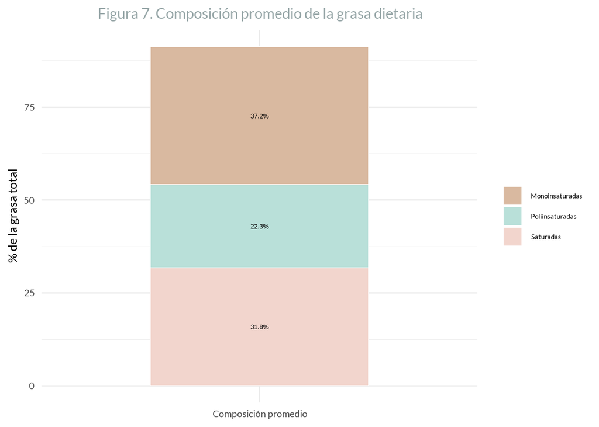

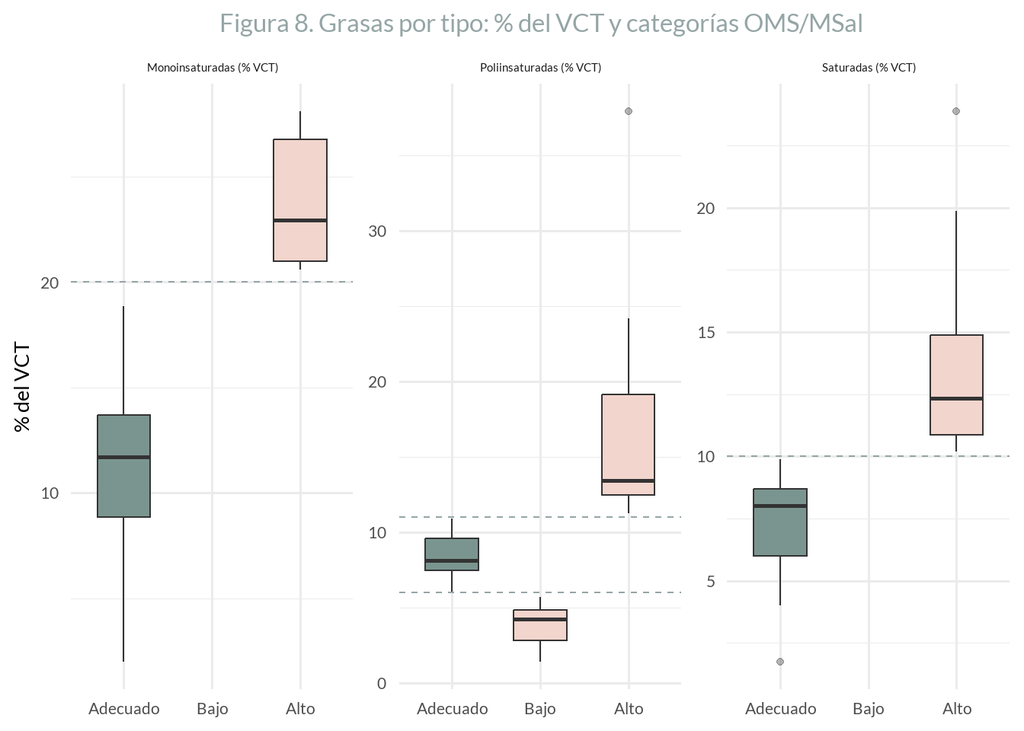

La ingesta media de grasa total fue 52,5 g/día (DE 26,4; 5,3–144,1). La composición relativa de la fracción lipídica mostró predominio de monoinsaturadas (~37%), seguida por saturadas (~32%) y poliinsaturadas (~22%). En términos energéticos, se observó una proporción relevante de participantes con saturadas >10% del VCT y con monoinsaturadas >20% del VCT, mientras que las poliinsaturadas fueron con frecuencia bajas (<6% del VCT), con pocos casos por encima del rango adecuado (6–11%). En conjunto, el perfil lipídico combina exceso de saturadas/monoinsaturadas y déficit de poliinsaturadas respecto de los umbrales OMS/MSal, sugiriendo margen de mejora en la calidad de la grasa dietaria (desplazamiento desde saturadas hacia fuentes ricas en AGPI).

# Variables de calidad de sueño

## Cálculo numérico de Pittsburgh

Tabla 6. Medidas descriptivas del puntaje Pittsburgh

| Media | Mediana | Desvío | Mín | Máx |
| --- | --- | --- | --- | --- |
| 5.3 | 5 | 2.5 | 2 | 14 |

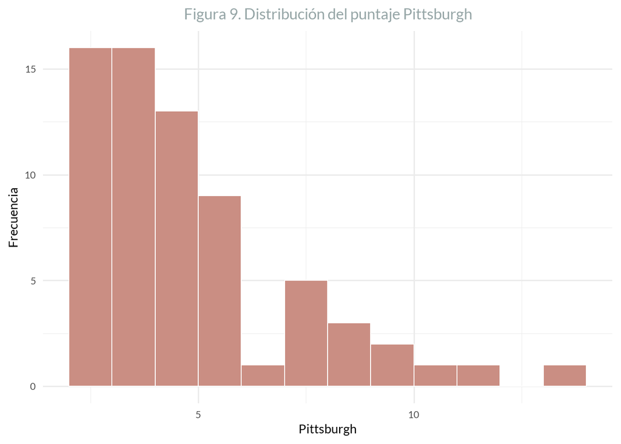

## Calidad de sueño

Tabla 7. Distribución de la calidad del sueño según Pittsburgh

| Calidad de sueño | Frecuencia | Porcentaje |
| --- | --- | --- |
| Buena calidad | 45 | 66.2% |
| Mala calidad | 23 | 33.8% |

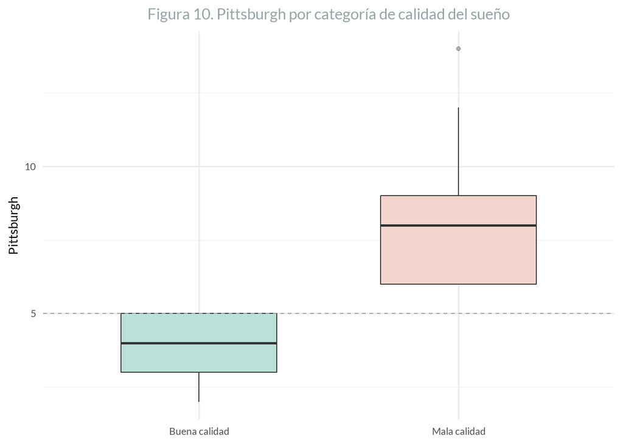

En esta muestra predominan puntuaciones bajas–moderadas de Pittsburgh, pero un tercio supera el punto de corte, indicando una proporción relevante con mala calidad de sueño y variabilidad marcada dentro de este subgrupo.